# PD5

Marta Jóźwik

9 listopada 2016

W tym tygodniu znalzałam w Gazecie Prawnej artykuł o długach lokatorów (str. A12), do którego dołączone były dodatkowe dane w postaci ramki na górze. Patrząc na 2 pierwsze wykresy wydaje mi się, że zostały one przedatwione w taki sposób, że trzeba się mocno zastanowić zanim np. dojdziemy do wniosku, że (mimo tytułu artykułu :“Długi lokatorów zmalały”) to długi przypadające na 1 mieszkanie w większości wzrastały, szczególnie dla długów pow. 3 miesięcy. Sądzę, że na przedstawionym wykresie łatwiej zauważyć takie zależności. W gazecie również musiałam się trochę naszukać co mają znaczyć 2 kolory słupków (inf. na górze o latach jest zbyt łatwo zauważalna, a przecież stanowi ona główny temat). Tak samo podpisy słupków są zbyt rozrzucone i trudno porównać te dwa wykresy do siebie.

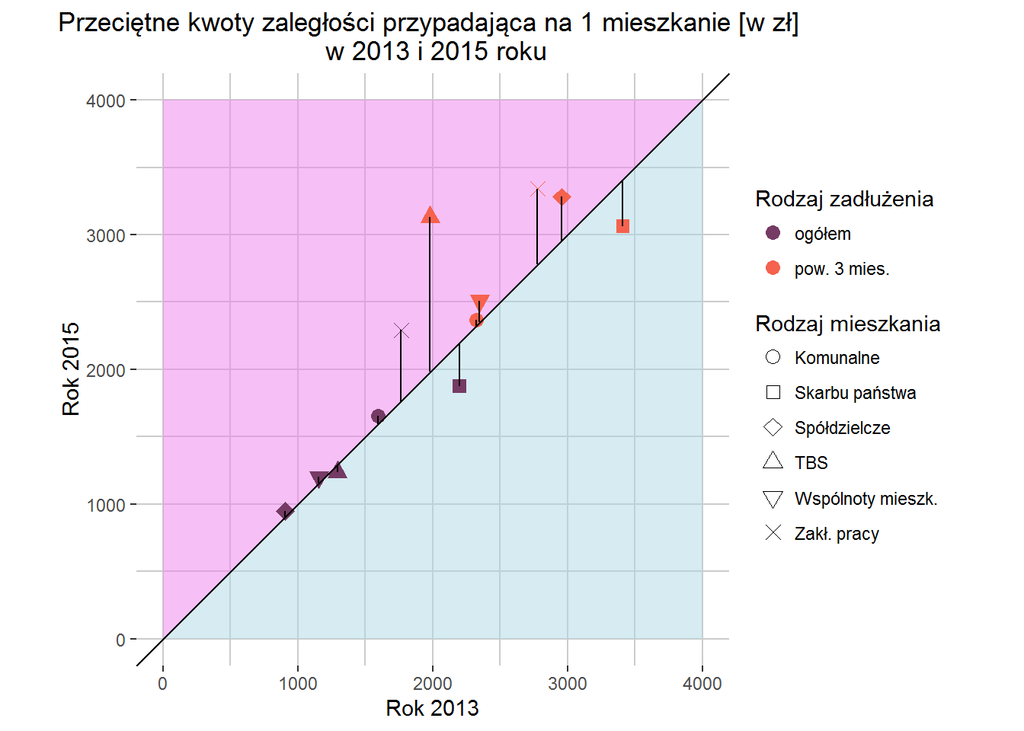

Drugą część zawartych danych przedstawiono w postaci tabelki, co oczywiście utrudnia zauważenie w nich od razu pewnych zależności (że praktycznie wszystkie wart. maleją). Trudno też zwizualizować sobie w jakim stopniu zmalały. Również na I rzut oka wydawało mi się że jest tam błąd (procenty sumowały się do >100), ale po uważniejszym wpatrzeniu się w nawiasie drobnym drukiem jest inf. o tym, że są to po prostu procenty zadłużeń w każdej grupie mieszkań. Sądzę, że przedstwione niżej wykresy są lepszą możliwością przedstawienia takich danych niż tabela.

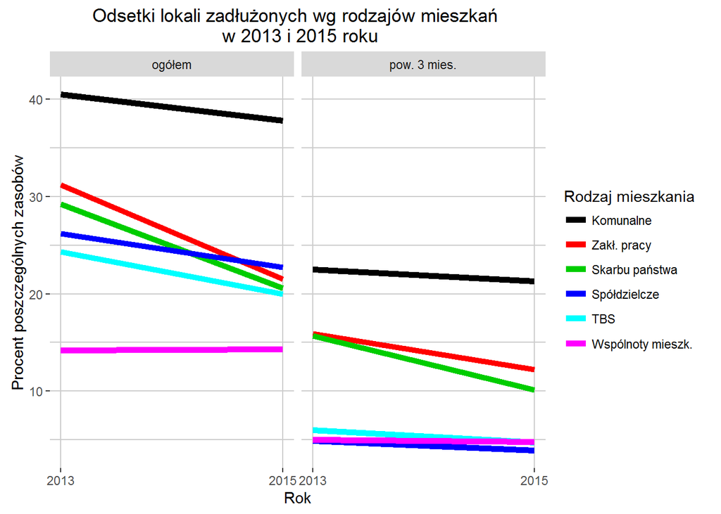